# Modelos lineales: especificación, diagnóstico y comunicación de resultados

# 5. Visualización de Coeficientes e Intervalos de Confianza

### ¿Por qué gráficos de coeficientes en lugar de tablas?

Las tablas de regresión son indispensables para la comunicación técnica, pero tienen una limitación importante: obligan al lector a procesar números individualmente para hacerse una idea visual del tamaño y la precisión de cada efecto. Un **gráfico de coeficientes** (*coefficient plot* o *coefplot*) resuelve esto de forma inmediata. Las visualizaciones

1. **Facilitan la comparación** del tamaño relativo de los efectos.
2. **Muestran la incertidumbre** de forma intuitiva: barras de error más largas = estimaciones menos precisas.
3. **Permiten evaluar la significancia estadística a simple vista**: si el intervalo de confianza cruza la línea del cero ($\beta = 0$), el coeficiente no es estadísticamente distinto de cero al nivel de confianza elegido.

### Construyendo el coefplot con `tidy()` y `ggplot2`

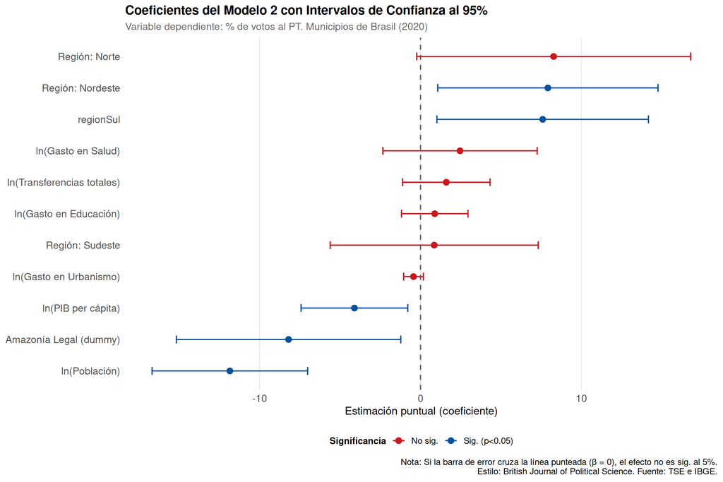

```r
# ----------------------------------------------------------
# Extraemos los coeficientes del Modelo 2 con tidy()
# Pedimos los intervalos de confianza al 95%

coefs_plot <- broom::tidy(modelo_2, conf.int = TRUE, conf.level = 0.95) |>
  # Eliminamos el intercepto (su escala es muy diferente
  # y distorsiona visualmente el gráfico)
  filter(term != "(Intercept)") |>
  # Renombramos las variables usando el mismo mapa que antes
  mutate(
    etiqueta = case_match(
      term,
      "(Intercept)"                          ~ "Intercepto",
      "log(gdp_per_capita)"                  ~ "ln(PIB per cápita)",
      "log(population)"                      ~ "ln(Población)",
      "gdp_per_capita"                       ~ "PIB per cápita",
      "population"                           ~ "Población",
      "transfer_n"                           ~ "Transferencias totales",
      "log(transfer_n)"                      ~ "ln(Transferencias totales)",
      "log(health_exp + 1)"                  ~ "ln(Gasto en Salud)",
      "log(educ_exp + 1)"                    ~ "ln(Gasto en Educación)",
      "log(urban_exp + 1)"                   ~ "ln(Gasto en Urbanismo)",
      "health_exp"                           ~ "Gasto en Salud",
      "educ_exp"                             ~ "Gasto en Educación",
      "urban_exp"                            ~ "Gasto en Urbanismo",
      "regionSudeste"                        ~ "Región: Sudeste",
      "regionCentro-Oeste"                   ~ "Región: Centro-Oeste",
      "regionNordeste"                       ~ "Región: Nordeste",
      "regionNorte"                          ~ "Región: Norte",
      "legal_amazon"                         ~ "Amazonía Legal (dummy)",
      "log(transfer_n):regionSudeste"       ~ "ln(Transferencias) × Sudeste",
      "log(transfer_n):regionCentro-Oeste"  ~ "ln(Transferencias) × Centro-Oeste",
      "log(transfer_n):regionNordeste"      ~ "ln(Transferencias) × Nordeste",
      "log(transfer_n):regionNorte"         ~ "ln(Transferencias) × Norte",
      .default = term          # Si no está en el mapa, muestra el nombre original
    ),
    # Marcamos si el coeficiente es estadísticamente significativo
    # para colorear de forma diferente en el gráfico
    significativo = ifelse(p.value < 0.05, "Sig. (p<0.05)", "No sig.")
  )

# ----------------------------------------------------------
# Los puntos son los coeficientes; las barras de error son
# los intervalos de confianza al 95%.
# La línea vertical en cero es la referencia clave:
# si la barra la cruza, el efecto no es sig. al 5%.
# ----------------------------------------------------------
ggplot(
  coefs_plot,
  aes(
    x     = estimate,
    y     = reorder(etiqueta, estimate),  # Ordenamos de menor a mayor
    color = significativo
  )
) +
  # Línea de referencia en cero (β = 0)
  geom_vline(
    xintercept = 0,
    linetype   = "dashed",
    color      = "gray40",
    linewidth  = 0.7
  ) +
  # Barras de error: intervalos de confianza al 95%
  geom_errorbarh(
    aes(xmin = conf.low, xmax = conf.high),
    height    = 0.25,
    linewidth = 0.7
  ) +
  # Puntos: estimadores puntuales
  geom_point(size = 3) +
  # Paleta de colores: rojo para no sig., azul para sig.
  scale_color_manual(
    values = c("Sig. (p<0.05)" = "#08519C", "No sig." = "#CB181D"),
    name   = "Significancia"
  ) +
  labs(
    title    = "Coeficientes del Modelo 2 con Intervalos de Confianza al 95%",
    subtitle = "Variable dependiente: % de votos al PT. Municipios de Brasil (2020)",
    x        = "Estimación puntual (coeficiente)",
    y        = NULL,
    caption  = "Nota: Si la barra de error cruza la línea punteada (β = 0), el efecto no es sig. al 5%.\nEstilo: British Journal of Political Science. Fuente: TSE e IBGE."
  ) +
  theme_minimal(base_size = 13) +
  theme(
    plot.title       = element_text(face = "bold", size = 15),
    plot.subtitle    = element_text(size = 12, color = "gray40"),
    axis.text.y      = element_text(size = 12),
    axis.text.x      = element_text(size = 12),
    legend.position  = "bottom",
    legend.title     = element_text(size = 11, face = "bold"),
    panel.grid.minor = element_blank(),
    panel.grid.major.y = element_blank()  # Sin líneas horizontales (estilo BJPolS)
  )
```

### Comparando coeficientes de los tres modelos

Una extensión muy útil del *coefplot* es comparar los coeficientes de variables clave a través de los tres modelos, para evaluar la **robustez** de los hallazgos.

Si el coeficiente de `legal_amazon` mantiene su signo y magnitud al cambiar la especificación, la evidencia sobre la pertenencia a esta región es mayor.

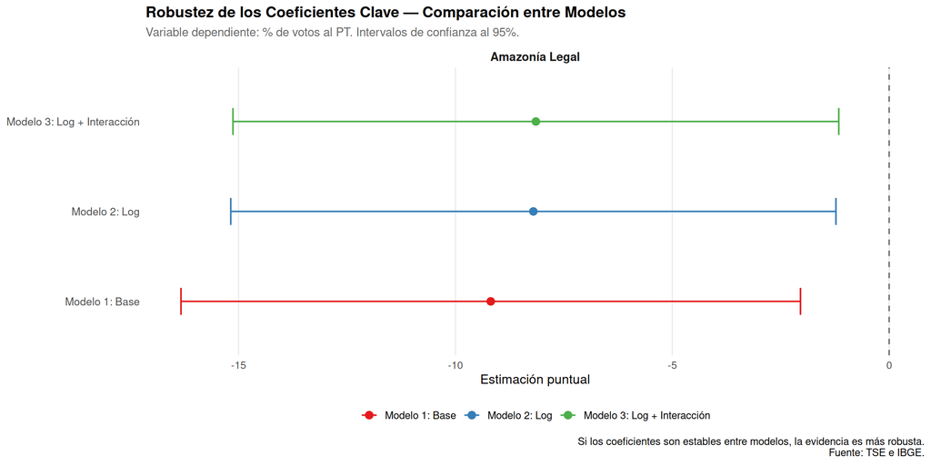

```r
# ----------------------------------------------------------
# Combinamos los coeficientes de los tres modelos en un solo
# dataframe, identificando a cuál pertenece cada uno.
# Filtramos las variables que aparecen en los tres modelos
# (en nivel, sin transformaciones) para una comparación limpia.

variables_comunes <- c(
  "legal_amazon"
)

df_coefs_comparacion <- bind_rows(
  broom::tidy(modelo_1, conf.int = TRUE) |> mutate(modelo = "Modelo 1: Base"),
  broom::tidy(modelo_2, conf.int = TRUE) |> mutate(modelo = "Modelo 2: Log"),
  broom::tidy(modelo_3, conf.int = TRUE) |> mutate(modelo = "Modelo 3: Log + Interacción")
) |>
  filter(term %in% variables_comunes) |>
  mutate(
    etiqueta = case_match(
      term,
     "legal_amazon"   ~ "Amazonía Legal"
    ),
    modelo = factor(
      modelo,
      levels = c("Modelo 1: Base", "Modelo 2: Log", "Modelo 3: Log + Interacción")
    )
  )

# ----------------------------------------------------------
# Gráfico de comparación entre modelos
# Usamos facet_wrap para separar por variable
# y coloreamos por modelo

ggplot(
  df_coefs_comparacion,
  aes(x = estimate, y = modelo, color = modelo)
) +
  geom_vline(
    xintercept = 0,
    linetype   = "dashed",
    color      = "gray40",
    linewidth  = 0.6
  ) +
  geom_errorbarh(
    aes(xmin = conf.low, xmax = conf.high),
    height    = 0.3,
    linewidth = 0.7
  ) +
  geom_point(size = 3) +
  facet_wrap(~ etiqueta, scales = "free_x", ncol = 3) +
  scale_color_brewer(palette = "Set1") +
  labs(
    title    = "Robustez de los Coeficientes Clave — Comparación entre Modelos",
    subtitle = "Variable dependiente: % de votos al PT. Intervalos de confianza al 95%.",
    x        = "Estimación puntual",
    y        = NULL,
    color    = NULL,
    caption  = "Si los coeficientes son estables entre modelos, la evidencia es más robusta.\nFuente: TSE e IBGE."
  ) +
  theme_minimal(base_size = 12) +
  theme(
    plot.title       = element_text(face = "bold", size = 14),
    plot.subtitle    = element_text(size = 11, color = "gray40"),
    legend.position  = "bottom",
    strip.text       = element_text(face = "bold", size = 11),
    panel.grid.minor = element_blank(),
    panel.grid.major.y = element_blank(),
    axis.text.y      = element_text(size = 10)
  )
```

**Nota**

**¿Qué observar en el gráfico de robustez?**

Si el coeficiente de `legal_amazon` mantiene el signo y es estadísticamente significativo en los tres modelos, tenemos evidencia robusta de un vínculo entre dicha región y el voto al PT.

Si el coeficiente cambia drásticamente entre modelos, hay que investigar qué variable o transformación está absorbiendo parte del efecto (posible colinealidad o especificación incorrecta).

# Extra: Regresión Beta

La regresión beta es la alternativa natural cuando la variable dependiente es una proporción acotada. A diferencia de OLS, que puede predecir valores fuera del rango posible (porcentajes negativos o mayores a 100), la regresión beta modela directamente la distribución de una variable en (0, 1) respetando sus límites matemáticos, lo que resuelve el patrón de “tijeretazo” que veíamos en el gráfico de residuos.

**ImportanteRecaudos**

1. La variable debe transformarse a proporción (dividir por 100) y no puede contener valores exactamente iguales a 0 o 1, para lo cual aplicamos una corrección estándar.
2. Los coeficientes ya no se interpretan en puntos porcentuales sino en escala de *log-odds* yaque internamente transforma el output en *logit* (de *(0,1)* a *(-inf, inf)*), por lo que para comunicar efectos sustanciales conviene calcular efectos marginales o graficar predicciones.

```r
# La regresión beta requiere el paquete betareg
if (!require("betareg")) install.packages("betareg")
library(betareg)

# ----------------------------------------------------------
# La regresión beta exige que Y esté estrictamente en (0, 1)
# Transformamos pct_pt a proporción y aplicamos la corrección

n_obs <- nrow(df_modelo)

df_modelo <- df_modelo |>
  mutate(
    prop_pt = pct_pt / 100,
    # Corrección estándar: empuja los 0s y 1s exactos levemente hacia adentro
    prop_pt_adj = (prop_pt * (n_obs - 1) + 0.5) / n_obs
  )

# ----------------------------------------------------------
# Modelo Beta con las mismas variables que el Modelo 3
# La fórmula es idéntica; betareg usa un link logit por defecto
# (equivalente a modelar log-odds de la proporción)

modelo_beta <- betareg(
  prop_pt_adj ~
    log(gdp_per_capita)      +
    log(population)          +
    log(transfer_n) * region +
    log(health_exp + 1)      +
    log(educ_exp   + 1)      +
    log(urban_exp  + 1)      +
    legal_amazon,
  data = df_modelo
)

summary(modelo_beta)
```

```
Call:
betareg(formula = prop_pt_adj ~ log(gdp_per_capita) + log(population) +
    log(transfer_n) * region + log(health_exp + 1) + log(educ_exp + 1) +
    log(urban_exp + 1) + legal_amazon, data = df_modelo)

Quantile residuals:
    Min      1Q  Median      3Q     Max
-3.1847 -0.7143  0.0431  0.6764  6.2367

Coefficients (mean model with logit link):
                               Estimate Std. Error z value Pr(>|z|)
(Intercept)                     0.37867    1.72821   0.219  0.82657
log(gdp_per_capita)            -0.09383    0.09136  -1.027  0.30438
log(population)                -0.73156    0.13174  -5.553 2.81e-08 ***
log(transfer_n)                 0.46325    0.18412   2.516  0.01187 *
regionSul                       3.32235    1.20589   2.755  0.00587 **
regionSudeste                   1.72192    1.30316   1.321  0.18639
regionNordeste                  1.32902    1.27922   1.039  0.29883
regionNorte                     0.58088    1.40822   0.412  0.67998
log(health_exp + 1)             0.11802    0.13288   0.888  0.37444
log(educ_exp + 1)               0.07005    0.05671   1.235  0.21673
log(urban_exp + 1)             -0.01001    0.01622  -0.617  0.53699
legal_amazon                   -0.39192    0.19108  -2.051  0.04027 *
log(transfer_n):regionSul      -0.43053    0.17505  -2.459  0.01392 *
log(transfer_n):regionSudeste  -0.22903    0.18650  -1.228  0.21944
log(transfer_n):regionNordeste -0.17362    0.17831  -0.974  0.33019
log(transfer_n):regionNorte    -0.05400    0.19660  -0.275  0.78357

Phi coefficients (precision model with identity link):
      Estimate Std. Error z value Pr(>|z|)
(phi)   3.0780     0.1366   22.53   <2e-16 ***
---
Signif. codes:  0 '***' 0.001 '**' 0.01 '*' 0.05 '.' 0.1 ' ' 1

Type of estimator: ML (maximum likelihood)
Log-likelihood: 515.7 on 17 Df
Pseudo R-squared: 0.1709
Number of iterations: 28 (BFGS) + 5 (Fisher scoring)
```

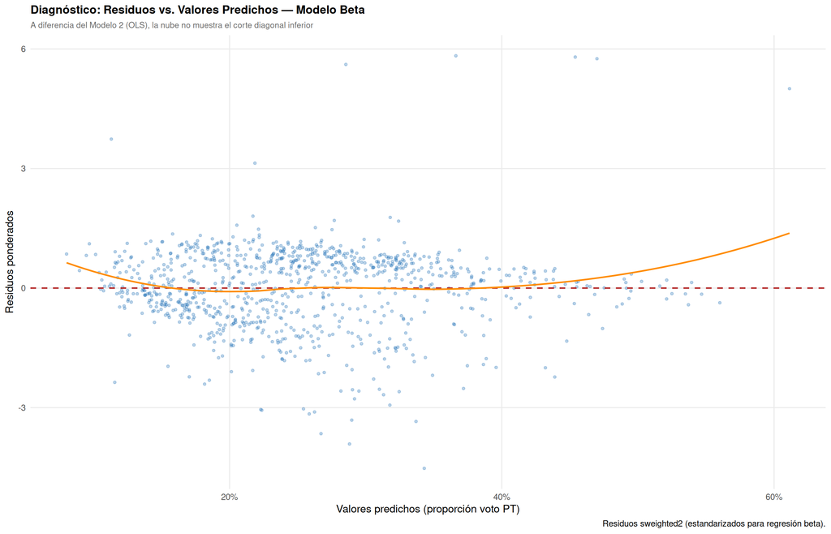

Figura 5

```r
ggplot(
  data.frame(
    fitted   = fitted(modelo_beta),
    residuos = residuals(modelo_beta, type = "sweighted2")
  ),
  aes(x = fitted, y = residuos)
) +
  geom_point(alpha = 0.3, color = "#2171B5", size = 1.2) +
  geom_hline(yintercept = 0, color = "firebrick",
             linetype = "dashed", linewidth = 0.8) +
  geom_smooth(method = "loess", se = FALSE,
              color = "darkorange", linewidth = 0.9) +
  scale_x_continuous(labels = scales::label_percent(scale = 100)) +
  labs(
    title    = "Diagnóstico: Residuos vs. Valores Predichos — Modelo Beta",
    subtitle = "A diferencia del Modelo 2 (OLS), la nube no muestra el corte diagonal inferior",
    x        = "Valores predichos (proporción voto PT)",
    y        = "Residuos ponderados",
    caption  = "Residuos sweighted2 (estandarizados para regresión beta)."
  ) +
  theme_minimal(base_size = 13) +
  theme(
    plot.title       = element_text(face = "bold", size = 14),
    plot.subtitle    = element_text(size = 10, color = "gray40"),
    panel.grid.minor = element_blank()
  )
```